# Статистический анализ данных (задание 2).

Работа с реальными данными. Проверка гипотез.

Юлия Лукашкина, 417 группа

Требуется подобрать и применить наилучший статистический метод, позволяющий ответить на вопрос прикладной задачи; обосновать выбор метода, его применимость и оптимальность. Помимо выводов, касающихся математических особенностей решения, необходимо в терминах предметной области сформулировать выводы, которые могли бы быть понятны гипотетическому заказчику-нематематику.

```
Измерено 150 черепов, найденных при раскопках в Египте. Находки относятся к пяти различным временным периодам. Для каждого черепа известны: максимальная ширина, базибрегматическая высота, базиальвеолярная длина, высота носа, примерная дата формирования.
```

Задание: *проверить, есть ли различия между размерами черепов различных временных периодов*?

Загрузка данных:

```r
skulls <- read.delim("Q:/PSAD/task2/skulls.txt")
colnames(skulls) <- c("w", "h", "l", "n", "y")
```

Посмотрим, что из себя представляют данные.

```r
str(skulls)
```

```
## 'data.frame':    150 obs. of  5 variables:
##  $ w: int  131 125 131 119 136 138 139 125 131 134 ...
##  $ h: int  138 131 132 132 143 137 130 136 134 134 ...
##  $ l: int  89 92 99 96 100 89 108 93 102 99 ...
##  $ n: int  49 48 50 44 54 56 48 48 51 51 ...
##  $ y: int  -4000 -4000 -4000 -4000 -4000 -4000 -4000 -4000 -4000 -4000 ...
```

```r
table(skulls$y)
```

```
##
## -4000 -3300 -1850  -200   150
##    30    30    30    30    30
```

Видно, что распределение числа черепов по разным временным эпохам равномерно. Рассмотрим гипотезу о равенстве средних значений **максимальной ширины** черепов разных периодов.

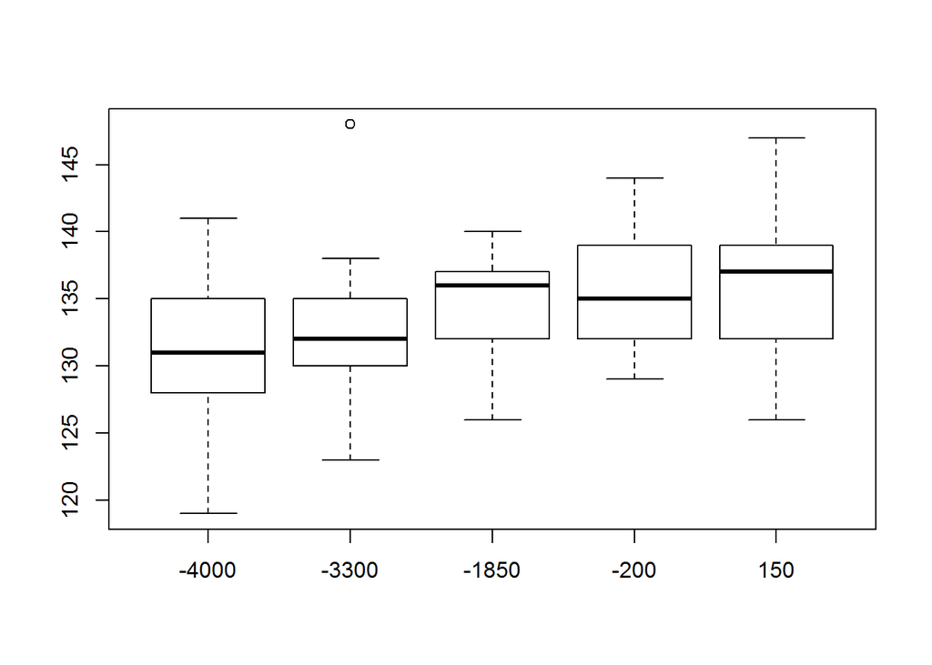

```r
boxplot(skulls$w ~ skulls$y)
```

Выясним, нормальны ли распределения значения ширины черепов внутри каждого периода, применим критерий Шапиро-Уилка для проверки нормальности, p-values:

```
##      -4000      -3300      -1850       -200        150
## 0.86034241 0.04028773 0.03138731 0.36078092 0.80394329
```

Для данных за период времени -1850 и -3300 гипотеза о нормальности не подтверждаются, поэтому будем использовать методы, не требующие нормальности выборок. Будем использовать критерий знаковых рангов Уилкоксона для проверки равенства медиан, данный ритери проверяет гипотезу

$H_0:\;med X = m_0;$ против альтернативы

$H1:\;med X \ne m_0.$

```r
pairwise.wilcox.test(skulls$w, skulls$y, p.adjust.method="none")
```

```
##
##  Pairwise comparisons using Wilcoxon rank sum test
##
## data:  skulls$w and skulls$y
##
##       -4000  -3300  -1850  -200
## -3300 0.6034 -      -      -
## -1850 0.0130 0.0250 -      -
## -200  0.0020 0.0046 0.4716 -
## 150   0.0015 0.0038 0.1414 0.5097
##
## P value adjustment method: none
```

Без поправки на множественность отвергаются гипотезы о равенстве средних значений максимальной ширины черепов у пар

- -4000 -1850
- -4000 -200
- -4000 150
- -3300 -1850
- -3300 -200
- -3300 150

Так как мы рассматримаем задачу множественной проверки гипотез, рассмотрим поправку на множественность. Так как m (количество гипотез) достаточно мало, то можно применить поправку Бонферрони не беспокоясь о мощность статистической процедуры.

```r
pairwise.wilcox.test(skulls$w,skulls$y, p.adjust.method="bonferroni")
```

```
##
##  Pairwise comparisons using Wilcoxon rank sum test
##
## data:  skulls$w and skulls$y
##
##       -4000 -3300 -1850 -200
## -3300 1.000 -     -     -
## -1850 0.130 0.250 -     -
## -200  0.020 0.046 1.000 -
## 150   0.015 0.038 1.000 1.000
##
## P value adjustment method: bonferroni
```

C учетом поправки отвергаются гипотезы о равенстве средних значений максимальной ширины черепов у пар:

- -4000 -200
- -4000 150
- -3300 -200
- -3300 150

Используем Критерий Джонкхиера для проверки гипотезы равенства средних против альтернативы их увеличения.

$H_0:\; med X_1 = \dots = med X_m$

$H_1:\; med X_1 \le \dots \le med X_m$

```r
library(clinfun)
jonckheere.test(skulls$w, skulls$y, alternative = "increasing")
```

```
##
##  Jonckheere-Terpstra test
##
## data:
## JT = 5860, p-value = 3.172e-06
## alternative hypothesis: increasing
```

p-value свидетельствует против нулевой гипотезы в пользу альтернативы. Можно сделать вывод, что среднее значение ширины черепа увеличивалось со временем.

Рассмотрим теперь показатели **базибрегматической высоты черепов**.

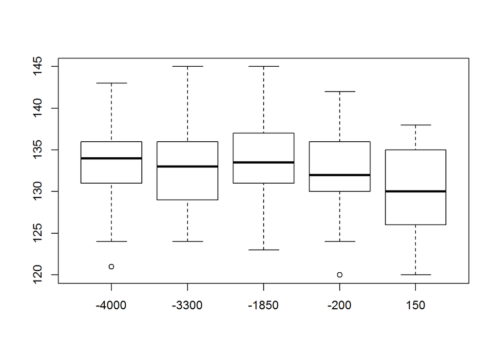

```r
par(mfrow=c(1,1))
boxplot(skulls$h ~ skulls$y)
```

```r
h <- split(skulls$h, skulls$y)
```

Проверим подвыборки на нормальность. p-values критерия Шапиро-Уилка для проверки нормальности:

```
##      -4000      -3300      -1850       -200        150
## 0.25361526 0.57986848 0.90306759 0.90000659 0.07767033
```

Гипотезы о нормальности не отвергаются, воспользуемся тестом Стьюдента для попарной проверки равенства средних с поправкой на множественность.

```r
pairwise.t.test(skulls$h,skulls$y, p.adjust.method="bonferroni")
```

```
##
##  Pairwise comparisons using t tests with pooled SD
##
## data:  skulls$h and skulls$y
##
##       -4000 -3300 -1850 -200
## -3300 1.000 -     -     -
## -1850 1.000 1.000 -     -
## -200  1.000 1.000 1.000 -
## 150   0.100 0.606 0.063 1.000
##
## P value adjustment method: bonferroni
```

Из полученных результатов можно сделать вывод, что средние значения базибрегматической высоты черепов примерно равны для различных периодов.

```r
bartlett.test(h~y, data=skulls)
```

```
##
##  Bartlett test of homogeneity of variances
##
## data:  h by y
## Bartlett's K-squared = 0.7315, df = 4, p-value = 0.9474
```

Гипотеза о равенстве дисперсий не отклоняется.

Рассмотрим значения **базиальвеолярной длины черепов**. Проверим гипотезу о равенстве их средних для различных временных эпох.

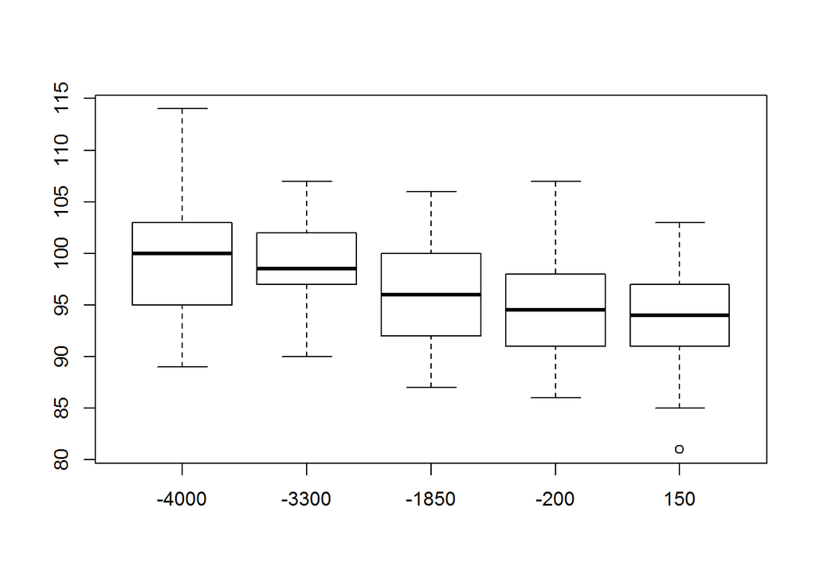

```r
boxplot(skulls$l ~ skulls$y)
```

```r
l <- split(skulls$l, skulls$y)
```

Проверим подвыборки на нормальность. p-values критерия Шапиро-Уилка для проверки нормальности:

```
##     -4000     -3300     -1850      -200       150
## 0.6282493 0.7494967 0.8849040 0.5275732 0.7733682
```

```r
jonckheere.test(skulls$l, skulls$y)
```

```
##
##  Jonckheere-Terpstra test
##
## data:
## JT = 2989, p-value = 5.281e-07
## alternative hypothesis: two.sided
```

Гипотеза о равенстве средних отклоняется. Общая гипотеза однородности отвергается, подвыборки – нормальные, воспользуемся LSD (Least Significant Difference) Фишера, получим красивый график.

```r
library(agricolae)
a1   <- aov(skulls$l~skulls$y)
LSD1 <- LSD.test(a1, "skulls$y", p.adj="none",console=TRUE)
```

```
##
## Study: a1 ~ "skulls$y"
##
## LSD t Test for skulls$l
##
## Mean Square Error:  23.84645
##
## skulls$y,  means and individual ( 95 %) CI
##
##       skulls.l      std  r      LCL       UCL Min Max
## -4000 99.16667 5.884423 30 97.40483 100.92850  89 114
## -3300 99.06667 4.346488 30 97.30483 100.82850  90 107
## -1850 96.03333 4.552251 30 94.27150  97.79517  87 106
## -200  94.53333 4.591847 30 92.77150  96.29517  86 107
## 150   93.50000 5.056576 30 91.73817  95.26183  81 103
##
## alpha: 0.05 ; Df Error: 148
## Critical Value of t: 1.976122
##
## Least Significant Difference 2.49161
## Means with the same letter are not significantly different.
##
## Groups, Treatments and means
## a     -4000   99.17
## a     -3300   99.07
## b     -1850   96.03
## bc    -200    94.53
## c     150     93.5
```

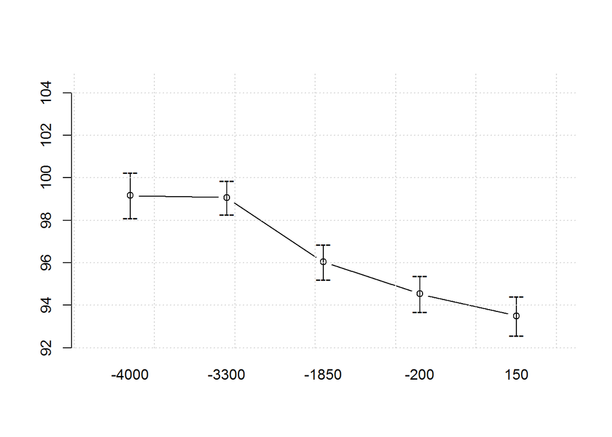

```r
bar.err(LSD1$means, variation="SE", ylim = c(92, 105), bar=FALSE,col=0)
grid()
```

Проверим гипотезу о равенстве средних против односторонней альтернативы их уменьшения.

$H_0:\; med X_1 = \dots = med X_m$

```r
jonckheere.test(skulls$l, skulls$y, alternative = "decreasing")
```

```
##
##  Jonckheere-Terpstra test
##
## data:
## JT = 2989, p-value = 2.641e-07
## alternative hypothesis: decreasing
```

Гипотеза о равенстве отвергается в пользу альтернативы. Средняя длина черепа уменьшалась с увеличением примерной даты формирования.

Рассмотрим данные о **высоте носа**.

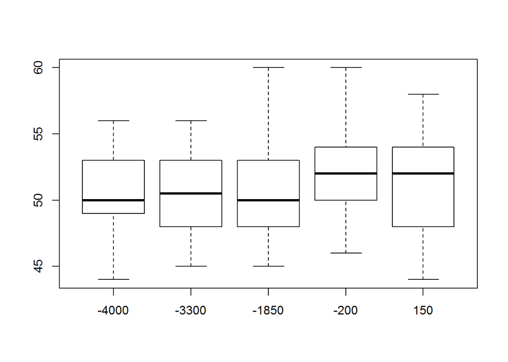

```r
boxplot(skulls$n ~ skulls$y)
```

```r
n <- split(skulls$n, skulls$y)
```

p-values критерия Шапиро-Уилка для проверки нормальности:

```
##     -4000     -3300     -1850      -200       150
## 0.6772417 0.3762163 0.3880582 0.2496396 0.6401080
```

```r
pairwise.t.test(skulls$n,skulls$y, p.adjust.method="bonferroni")
```

```
##
##  Pairwise comparisons using t tests with pooled SD
##
## data:  skulls$n and skulls$y
##
##       -4000 -3300 -1850 -200
## -3300 1.00  -     -     -
## -1850 1.00  1.00  -     -
## -200  0.84  0.37  0.91  -
## 150   1.00  1.00  1.00  1.00
##
## P value adjustment method: bonferroni
```

Гипотеза о равенстве средних не отвергается. Можно сделать вывод, что длина носа не зависит от периода формирования черепа.

По результатам полученным выше можно предположить, что все черепа можно примерно разделить на 2 группы: -4000, -3300 и -1850,-200, 150. Проверим данное предположение, исследуем значения ширины и длины черепов для двух данных групп.

```r
f <- factor(skulls$y == "-4000" | skulls$y == "-3300")
tmp <- split(skulls, f)
skulls_old   <- tmp[[2]]
skulls_young <- tmp[[1]]

shapiro.test(skulls_old$w)
```

```
##
##  Shapiro-Wilk normality test
##
## data:  skulls_old$w
## W = 0.976, p-value = 0.2846
```

```r
shapiro.test(skulls_young$w)
```

```
##
##  Shapiro-Wilk normality test
##
## data:  skulls_young$w
## W = 0.9873, p-value = 0.5347
```

```r
bartlett.test(w~f, data=skulls)
```

```
##
##  Bartlett test of homogeneity of variances
##
## data:  w by f
## Bartlett's K-squared = 1.2885, df = 1, p-value = 0.2563
```

```r
t.test(skulls_old$w, skulls_young$w, alternative="less")
```

```
##
##  Welch Two Sample t-test
##
## data:  skulls_old$w and skulls_young$w
## t = -4.4666, df = 114.718, p-value = 9.364e-06
## alternative hypothesis: true difference in means is less than 0
## 95 percent confidence interval:
##       -Inf -2.207582
## sample estimates:
## mean of x mean of y
##  131.8667  135.3778
```

95% доверительный интервал для разности: $(-\infty,\; -2.207582)$ Гипотеза о равенстве отвергается в пользу односторонней альтернативы. Проверим, что внутри групп средние совпадают.

```r
w <- split(skulls_old$w, skulls_old$y)
wilcox.test(w[[1]], w[[2]])
```

```
##
##  Wilcoxon rank sum test with continuity correction
##
## data:  w[[1]] and w[[2]]
## W = 414.5, p-value = 0.6034
## alternative hypothesis: true location shift is not equal to 0
```

```r
w <- split(skulls_young$w, skulls_young$y)
pairwise.wilcox.test(skulls_young$w,skulls_young$y, p.adjust.method="bonferroni")
```

```
##
##  Pairwise comparisons using Wilcoxon rank sum test
##
## data:  skulls_young$w and skulls_young$y
##
##      -1850 -200
## -200 1.00  -
## 150  0.42  1.00
##
## P value adjustment method: bonferroni
```

p-value большие, гипотеза о равенстве средних внутри групп принимается. Рассмотрим длину черепов.

```r
shapiro.test(skulls_old$l)
```

```
##
##  Shapiro-Wilk normality test
##
## data:  skulls_old$l
## W = 0.9854, p-value = 0.6896
```

```r
shapiro.test(skulls_young$l)
```

```
##
##  Shapiro-Wilk normality test
##
## data:  skulls_young$l
## W = 0.9916, p-value = 0.8403
```

```r
t.test(skulls_old$l, skulls_young$l, alternative="greater")
```

```
##
##  Welch Two Sample t-test
##
## data:  skulls_old$l and skulls_young$l
## t = 5.3129, df = 120.741, p-value = 2.502e-07
## alternative hypothesis: true difference in means is greater than 0
## 95 percent confidence interval:
##  3.046352      Inf
## sample estimates:
## mean of x mean of y
##  99.11667  94.68889
```

```r
l <- split(skulls_old$l, skulls_old$y)
wilcox.test(l[[1]], l[[2]])
```

```
##
##  Wilcoxon rank sum test with continuity correction
##
## data:  l[[1]] and l[[2]]
## W = 444.5, p-value = 0.9409
## alternative hypothesis: true location shift is not equal to 0
```

```r
l <- split(skulls_young$l, skulls_young$y)
pairwise.wilcox.test(skulls_young$w,skulls_young$y, p.adjust.method="bonferroni")
```

```
##
##  Pairwise comparisons using Wilcoxon rank sum test
##
## data:  skulls_young$w and skulls_young$y
##
##      -1850 -200
## -200 1.00  -
## 150  0.42  1.00
##
## P value adjustment method: bonferroni
```

Выводы:

- все черепа можно примерно разделить на 2 группы по временному периоду: -4000, -3300 и -1850,-200, 150. В первой группе средняя ширина черепа меньше, чем во второй. 95% доверительный интервал для разности средних: $(-\infty,\; -2.207582)$. Однако, средняя длина черепа больше в первой группе. 95% доверительный интервал для разности в длине черепа: $(3.046352,\;\infty)$.
- среднее значение ширины черепа увеличивалось со временем,
- средние значения базибрегматической высоты черепов примерно равны для различных периодов,
- длина черепа уменьшалась с увеличением примерной даты формирования,
- длина носа не зависит от периода формирования черепа